# First Exploration

Grégoire Lurton

June, 2016

# Files Reading and aggregation

Simple script to read and aggregate all files.

```r
data_path <- 'c://Users/grlurton/Google Drive/KenyaEMR/data/'

list_facilities <- list.files(data_path)

adult_cqi <- data.frame()
paed_cqi <- data.frame()
patient_enrollment <- data.frame()
patient_visits <- data.frame()
moh_731_a <- data.frame()
moh_731_b <- data.frame()

for (fac in list_facilities){
    adult_cqi <- rbind(adult_cqi , read.csv(paste0(data_path , fac,  '/Adult_CQI_final.csv')))
    paed_cqi <- rbind(paed_cqi , read.csv(paste0(data_path , fac,  '/Paeds_CQI_final.csv')))
    patient_enrollment <- rbind(patient_enrollment ,
                                read.csv(paste0(data_path , fac,
                                                '/kenyaEMR_Patient_initial_enrollment.csv')))
    patient_visits <- rbind(patient_visits ,
                            read.csv(paste0(data_path , fac,
                                            '/KenyaEMR_Visit_Encounters.csv')))
    moh_731_a <- rbind(moh_731_a ,
                       read.csv(paste0(data_path , fac,
                                       '/MOH731_Care_and_Treatment_3.1_3.8_indicators.csv')))
    moh_731_b <- rbind(moh_731_b ,
                       read.csv(paste0(data_path , fac,
                                       '/MOH731_PMTCT_OTHER_CARE_AND_TREATMENT_AND_MOH711_TB_INDICATORS.csv')))
}
```

Data reading and aggregation works fine. Only problem encountered was bad standardization of files names. Two file names had to be updated to match others.

**Please make extra sure the names of csv files are properly standardized so aggregation can happen without manual modification. This may be in the script or in the training of people making hte data extraction.**

## CQI Data

### Adult

Quick look at adult cqi data

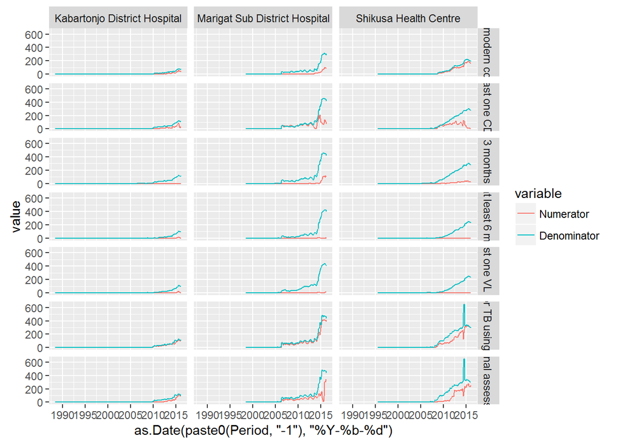

```r
library(reshape2)
melted_dat <- melt(adult_cqi , id = c("Facility_Name" , "Period" , 'MFL_Code' ,  'Indicator' , 'Name'))
library(ggplot2)
qplot(data = melted_dat , x = as.Date(paste0(Period , '-1') , "%Y-%b-%d") ,
      y  = value , col = variable , geom = 'line') +
  facet_grid(Name ~ Facility_Name)
```

There doesn’t seem to be any major problem with extraction of CQI adult data. Some outliers do not come from aggregation but probably come from actual data.

### Paediatrics

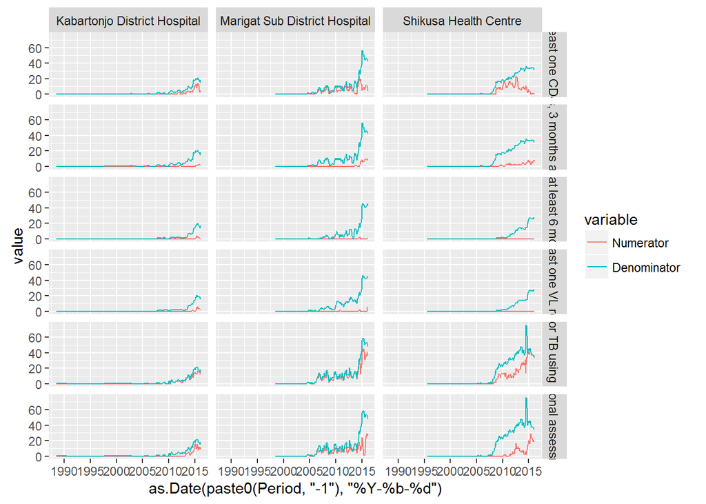

```r
library(reshape2)
melted_dat <- melt(paed_cqi , id = c("Facility_Name" , "Period" , 'MFL_Code' ,  'Indicator' , 'Name'))
library(ggplot2)

qplot(data = melted_dat , x = as.Date(paste0(Period , '-1') , "%Y-%b-%d") ,
      y  = value , col = variable , geom = 'line') +
  facet_grid(Name ~ Facility_Name)
```

There doesn’t seem to be any major problem with extraction of CQI paed data. Some outliers do not come from aggregation but probably come from actual data.

## Data Entry Metadata

```r
print(head(patient_enrollment))
```

```
##   MFL_CODE                Facility_Name     patient         Form_type
## 1    14609 Kabartonjo District Hospital   146090148    HIV Enrollment
## 2    14609 Kabartonjo District Hospital 14607001580    HIV Enrollment
## 3    14609 Kabartonjo District Hospital  1520403934 MOH 257 Face Page
## 4    14609 Kabartonjo District Hospital  1520404324 MOH 257 Face Page
## 5    14609 Kabartonjo District Hospital 14607006867    HIV Enrollment
## 6    14609 Kabartonjo District Hospital 14607006867 MOH 257 Face Page
##    form_creation_time    last_saving_time creatorLogin
## 1 2014-10-14 14:26:47                NULL     jkabutie
## 2 2014-09-23 15:51:57 2015-03-05 13:43:33     echerono
## 3 2014-11-19 18:04:00 2015-03-05 13:43:33      jarnota
## 4 2014-09-23 11:30:27 2015-03-05 13:43:33     jkabutie
## 5 2014-10-09 11:45:23 2015-03-05 13:43:33     jkabutie
## 6 2014-10-09 11:48:00 2015-03-05 13:43:33     jkabutie
##                                                 roles Enrollment_Date
```

[output cut: 20 more lines]

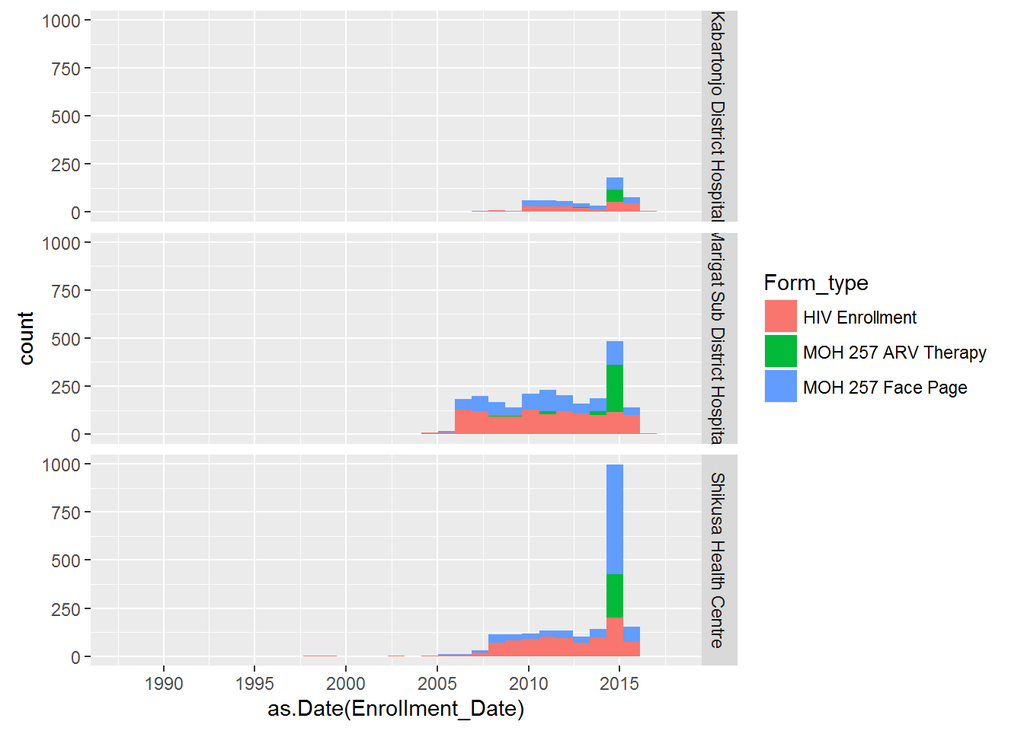

```r
qplot(data = patient_enrollment  ,
      x = as.Date(Enrollment_Date) , fill = Form_type) +
  facet_grid(Facility_Name~.)
```

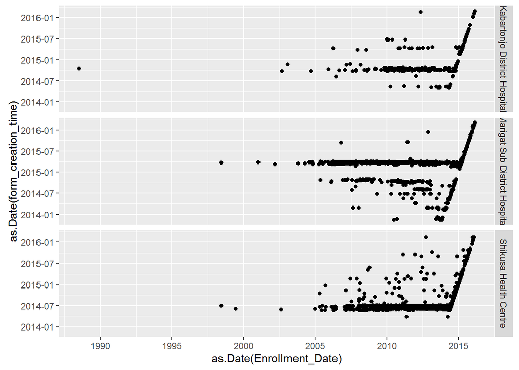

```r
patient_enrollment$time_to_entry <- as.numeric(difftime(as.Date(patient_enrollment$form_creation_time) ,
                                                           as.Date(patient_enrollment$Enrollment_Date)) ,
                                               units = 'days')




qplot(data = patient_enrollment , y = as.Date(form_creation_time) , x = as.Date(Enrollment_Date))+
  facet_grid(Facility_Name~.)
```

```r
print(summary(patient_enrollment$time_to_entry))
```

```
##    Min. 1st Qu.  Median    Mean 3rd Qu.    Max.
##   -28.0     0.0   639.0   954.5  1708.0  9602.0
```

There is a curious spike in enrollment happening at the time of data catch up. Probably error, to be accounted for.

The data entry timing looks ok.